# BF_Final_Exam

Ritik Kumar

2024-12-09

# Introduction to the Dataset:

# The dataset represents monthly car sales in the United States. This dataset provides insights into the sales trends and patterns over time. Car sales are an important indicator of economic health, reflecting consumer confidence and disposable income levels.

# The dataset contains two main variables:

# Date: The month and year of the recorded sales.

# Sales Units: The number of cars sold during each month.

# Objective:

# The goal is to perform a comprehensive time series analysis to:

# Analyze trends, seasonality, and irregularities in car sales.

# Forecast future sales using methods like Naïve, Moving Averages, Simple Smoothing, Holt-Winters, and ARIMA.

# Compare forecasting method accuracies to determine the best model.

## Importing the Data

```r
library(forecast)
library(fpp)
library(fpp2)
library(readr)
```

```r
library(ggplot2)
library(dplyr)
# Load the dataset
sales_data <- read_csv("C:/Users/malho/Downloads/BF_Final_Exam/TOTALSA.csv")
# Print the first few rows to understand the structure of data
print(head(sales_data))
```

```
## # A tibble: 6 × 2
##   Date     `Sales Units`
##   <chr>            <dbl>
## 1 1/1/2019          17.0
## 2 2/1/2019          17.0
## 3 3/1/2019          17.8
## 4 4/1/2019          17.0
## 5 5/1/2019          18.0
## 6 6/1/2019          17.8
```

- First we import the dataset and print the head of data to see our data must be succesfully uploaded or not.

##### Converting the dataset into Times Series object

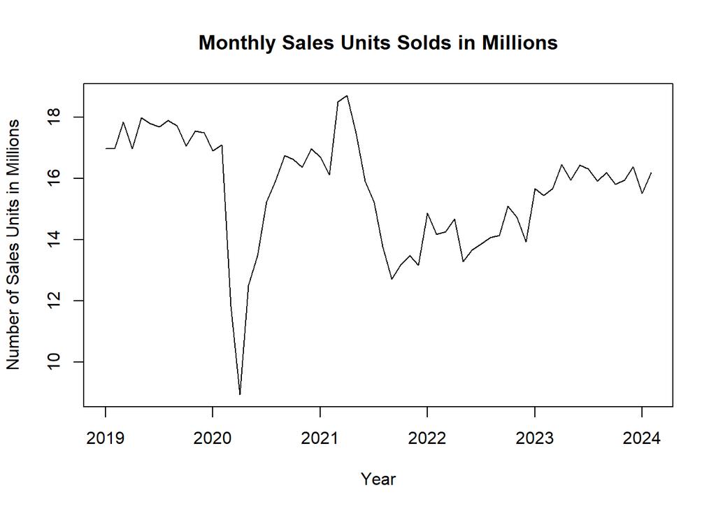

```r
# first Convert 'Date' column to Date type
sales_data$Date <- as.Date(sales_data$Date, format = "%m/%d/%Y")

# Converting data into Time Series
sales_ts <- ts(sales_data$`Sales Units`, start = c(2019, 1), frequency = 12)

# Plot the original time series data of Sales Units from 2019-2024 to confirm
plot(sales_ts, main = "Monthly Sales Units Solds in Millions", ylab = "Number of Sales Units in Millions", xlab = "Year")
```

##### Initial Observations

- From 2019 to 2020, sales appear stable but drop sharply around 2020.
- A significant rebound is visible post-2020, followed by fluctuating recovery trends from 2021 to 2024.
- No strong cyclical seasonal patterns are visible.
- The sharp dip in 2020 suggests an external factor affecting sales, possibly the pandemic.
- Sales gradually stabilize after 2021, showing economic recovery.
- If we have to forecast the data, we should be considering the window from 2021.

## Considering only a window from 2021 to 2024

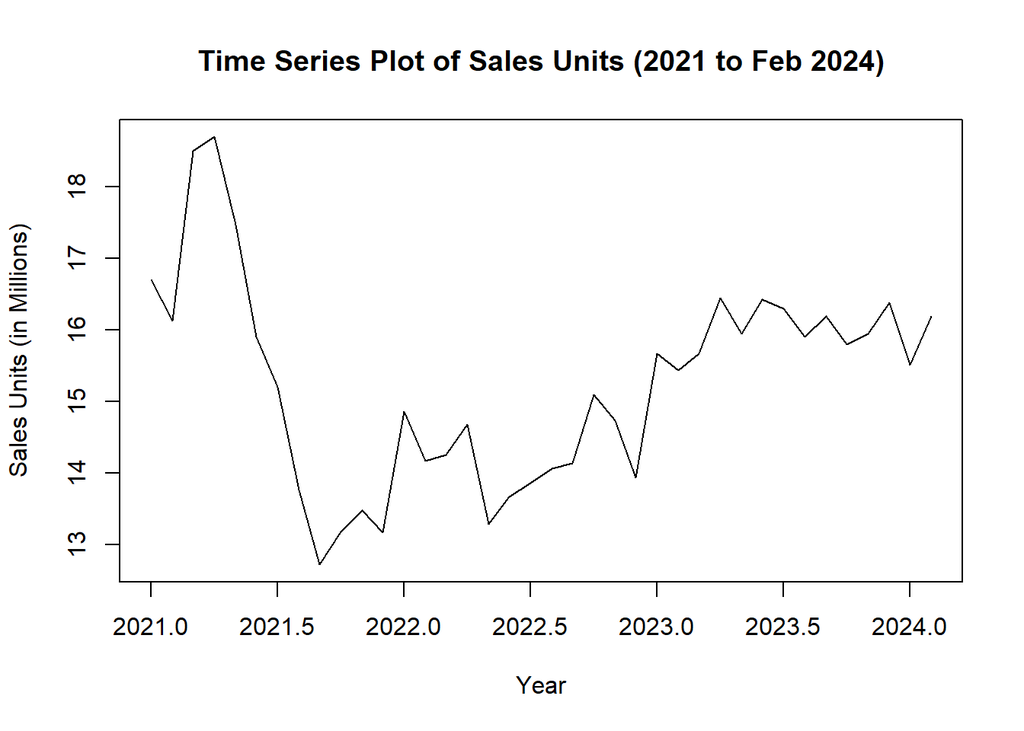

```r
# Creating a window of the time series from 2021 to February 2024
sales_ts_window <- window(sales_ts, start = c(2021,1), end = c(2024,2))

# Plot the window specific time series
plot(sales_ts_window, main = "Time Series Plot of Sales Units (2021 to Feb 2024)", xlab = "Year", ylab = "Sales Units (in Millions)")
```

## Identify Central Tendency

##### Min, max, mean, median, 1st and 3rd Quartile values of the times series

```r
summary(sales_ts_window)
```

```
##    Min. 1st Qu.  Median    Mean 3rd Qu.    Max.
##   12.72   14.08   15.47   15.25   16.17   18.70
```

- The summary function above gives the min, max, mean, median, 1st and 3rd Quartile values of the times series.
- The lowest monthly sales recorded during this period is 12.72 million units, which likely corresponds to the sharp dip seen in 2021.
- First Quartile (14.08 million units):25% of the months have sales below this value, indicating the lower range of sales during the recovery phase.
- Median (15.47 million units):Half of the months have sales below this value, representing the central tendency or “typical” monthly sales during this period.
- Mean (15.25 million units):The average monthly sales over the period are slightly lower than the median, suggesting that there are some lower values (e.g., the sharp dips in 2021) skewing the average downward.
- Third Quartile (16.17 million units):75% of the months have sales below this value, indicating the higher range of typical sales.
- Maximum Sales (Max):The highest monthly sales during this period is 18.70 million units, corresponding to the peak seen in 2021.

##### Key Observations:

- The range of sales (12.72 to 18.70 million units) highlights significant variation in monthly performance.
- The median (15.47) being close to the mean (15.25) indicates a relatively symmetric distribution of sales.
- The interquartile range (14.08 to 16.17) reflects the typical spread of monthly sales, with extremes being outliers or exceptional months.

##### Box Plot

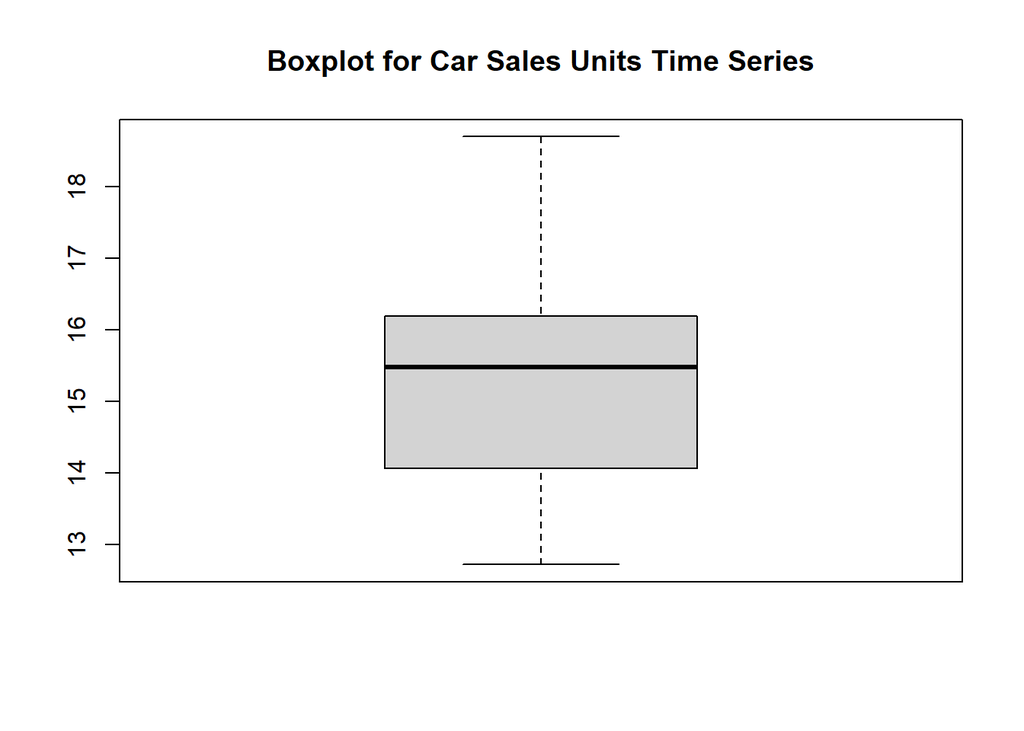

```r
boxplot(sales_ts_window, main ='Boxplot for Car Sales Units Time Series')
```

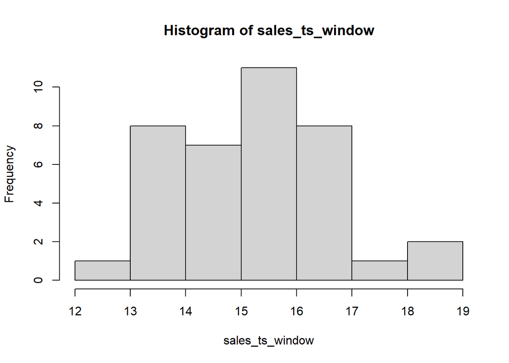

```r
hist(sales_ts_window)
```

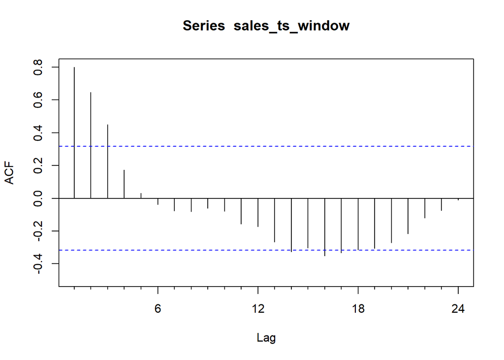

```r
Acf(sales_ts_window)
```

## Decomposition

##### Decomposition Plot

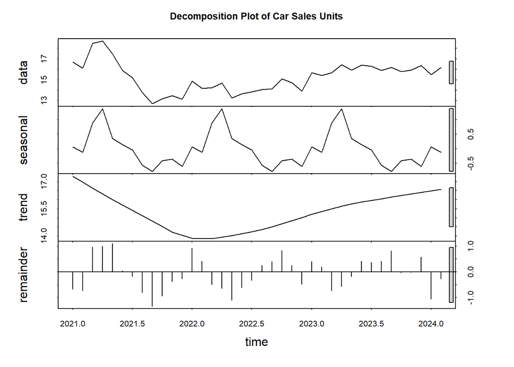

```r
stl_decomp <- stl(sales_ts_window, s.window = "periodic")
plot(stl_decomp, main = 'Decomposition Plot of Car Sales Units')
```

# Observation: * The original time series exhibits noticeable fluctuations, with both seasonal patterns and an overall trend. * Clear repeating seasonal patterns are observed, indicating regular monthly variations in sales. * Peaks and troughs occur consistently, suggesting predictable seasonal behavior. * A declining trend is evident during 2021, followed by a steady upward recovery from 2022 onwards. * This aligns with broader economic recovery post-pandemic. * Residuals are small and randomly distributed, confirming that most variations are well explained by the trend and seasonality.

##### Is the time series seasonal?

- Yes, the time series is seasonal, as evident from the consistent repeating pattern observed in the seasonal component of the decomposition plot.

##### Is the decomposition additive or multiplicative?

```r
decom <- decompose(sales_ts_window)
decom$type
```

```
## [1] "additive"
```

- The decomposition type is additive, meaning the time series can be expressed as: Data=Trend+Seasonality+Remainder
- This indicates that the seasonal fluctuations and residual variations are independent of the trend’s magnitude.

##### • If seasonal, what are the values of the seasonal monthly indices?

```r
decom$figure
```

```
##  [1]  0.92139294  0.38941377  0.43193461  0.90808044 -0.14423206  0.16891377
##  [7]  0.09866377 -0.43182234 -1.08637789 -0.27356539 -0.22254456 -0.75985706
```

- In time series decomposition, decom$figure refers to the seasonal component values extracted during the decomposition process in R.
- It shows how much the seasonal component contributes to or detracts from the overall value for each time point in a single cycle.
- Positive values indicate the time point contributes above average to the data.
- Negative values indicate it contributes below average to the data.

##### Observations and Inferences

- High Impact Months: January (0.92) and April (0.91) have strong positive indices, indicating higher sales.
- Low Impact Months: September (-1.09) and December (-0.76) show the lowest sales impact.
- Moderate Impact: February (0.39) and March (0.43) have mild positive indices; November (-0.22) shows slight negative impact.
- Seasonality: Clear monthly patterns influence sales, emphasizing the importance of seasonal adjustments.

##### Seasonality adjusted plot

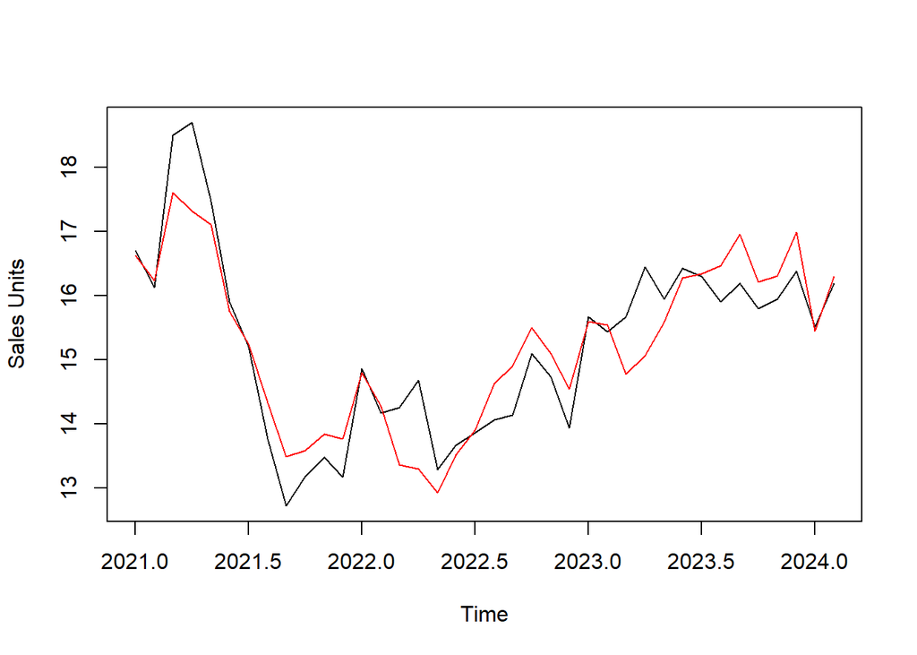

```r
plot(sales_ts_window, ylab = 'Sales Units')
lines(seasadj(stl_decomp), col="Red")
```

- There are repeated fluctuations that can be observed after applying seasonal adjustment.
- With time, these fluctuations will cause deviations and change our forecast. So, it is important to consider the seasonal variation in the data.
- The Black Line represents the raw sales data, including both trend and seasonal effects.
- Fluctuations are evident, influenced by both seasonality and irregular variations.
- The red line represents the time series after removing seasonal effects using the seasadj() function.
- The red line is smoother compared to the black line, focusing on the underlying trend and irregular components.
- The difference between the black and red lines highlights the seasonal fluctuations, which have been removed in the seasonally adjusted data.
- Seasonal adjustment makes it easier to observe long-term trends without seasonal distortions.
- The upward trend from 2022 onward is clearer in the red line, showing recovery in sales after the decline in 2021.

## Testing the various Forecasting methods for the given dataset

## Naive Method

- The naive forecasting method is one of the simplest forecasting techniques. It assumes that the most recent observed value is the best predictor for all future values. This method does not account for trends, seasonality, or other patterns in the data.

##### Output

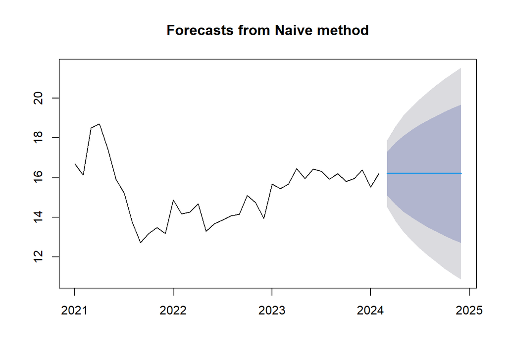

```r
naive_forecast <- naive(sales_ts_window)
plot(naive_forecast)
```

- The Naïve method forecasts a flat trend, using the most recent observed value as the baseline.
- The prediction interval widens over time, indicating increasing uncertainty in the forecast.
- The forecast does not account for seasonality or trends, reflecting the simplicity of the Naïve model.
- Suitable as a baseline but may not be optimal for capturing underlying patterns.

##### Perform Residual Analysis for this technique.

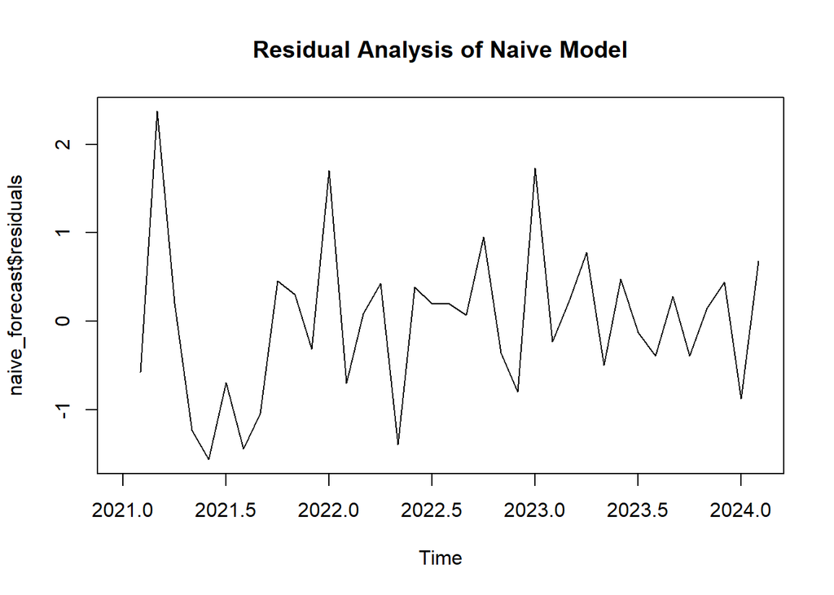

```r
plot(naive_forecast$residuals, main = "Residual Analysis of Naive Model")
```

- Residuals fluctuate around zero, indicating errors are centered on actual values.
- Visible patterns suggest the Naïve model does not capture trends and seasonality effectively.
- Large residual spikes (~-1 to +2) highlight periods with significant forecast errors.
- The Naïve model is a basic method and insufficient for accurate forecasting.

###### Residuals Histogram

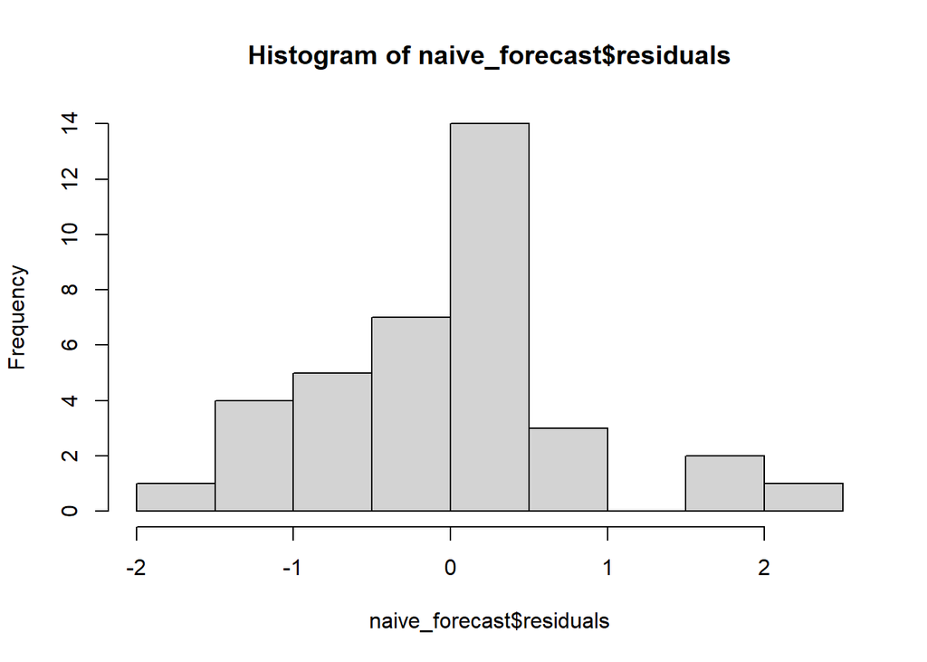

```r
hist(naive_forecast$residuals)
```

- Residuals are centered around zero, indicating minimal bias in the model.
- The majority of residuals fall between -1 and 1, showing relatively small errors.
- Few residuals are outside this range (~-2 and ~2), indicating occasional larger forecast errors.
- The distribution is slightly skewed, suggesting the Naïve model does not perfectly capture the data variability.

###### Fitted vs Residual Values

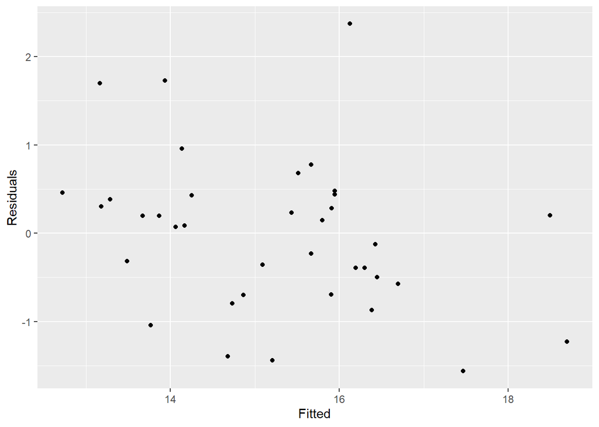

```r
cbind(Fitted = fitted(naive_forecast),
      Residuals = residuals(naive_forecast)) %>%
  as.data.frame() %>%
  ggplot( aes(x= Fitted, y= Residuals)) + geom_point()
```

- Residuals are scattered randomly around zero, suggesting no clear pattern.
- Variability in residuals increases slightly with fitted values, indicating potential heteroscedasticity.
- Lack of systematic patterns confirms the model’s residuals are reasonably well-behaved.
- Minor deviations suggest model improvements might capture additional structure in the data.

###### Actual vs Residual values

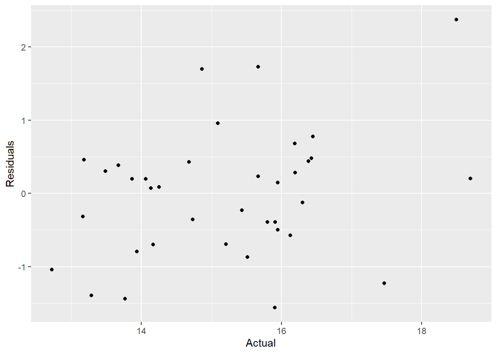

```r
cbind(Actual=sales_ts_window,
      Residuals=residuals(naive_forecast)) %>%
  as.data.frame() %>%
  ggplot(aes(x=Actual, y=Residuals)) + geom_point()
```

###### ACF of residuals

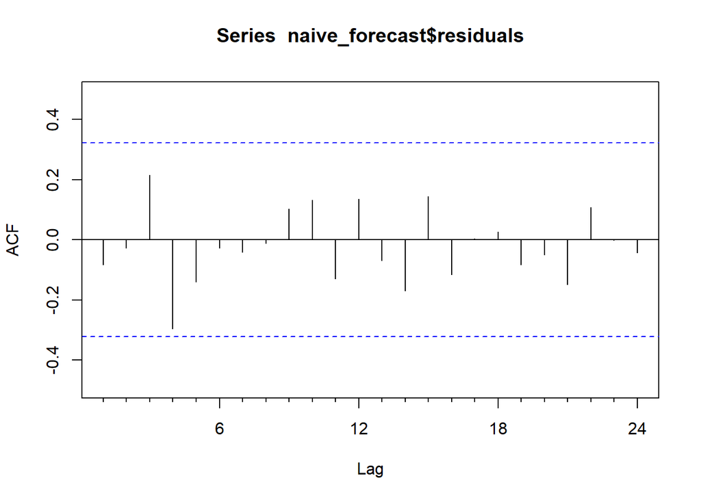

```r
Acf(naive_forecast$residuals)
```

- Residuals show minor autocorrelation at lower lags, indicating potential model inadequacy.
- Most lags fall within the confidence bounds, suggesting no significant autocorrelation overall.
- Slight patterns in the ACF plot suggest the Naïve model does not fully capture the data structure.
- A more sophisticated model might better account for trends and seasonality.

##### Accuracy

```r
accuracy(naive_forecast)
```

```
##                       ME      RMSE      MAE        MPE     MAPE      MASE
## Training set -0.01367568 0.8614528 0.669027 -0.2400275 4.390416 0.3644854
##                     ACF1
## Training set -0.08298117
```

##### Forecast

```r
forecast(naive_forecast)
```

```
##          Point Forecast    Lo 80    Hi 80    Lo 95    Hi 95
## Mar 2024         16.191 15.08700 17.29500 14.50258 17.87942
## Apr 2024         16.191 14.62971 17.75229 13.80322 18.57878
## May 2024         16.191 14.27882 18.10318 13.26658 19.11542
## Jun 2024         16.191 13.98301 18.39899 12.81417 19.56783
## Jul 2024         16.191 13.72239 18.65961 12.41559 19.96641
## Aug 2024         16.191 13.48677 18.89523 12.05524 20.32676
## Sep 2024         16.191 13.27010 19.11190 11.72387 20.65813
## Oct 2024         16.191 13.06843 19.31357 11.41544 20.96656
## Nov 2024         16.191 12.87901 19.50299 11.12575 21.25625
## Dec 2024         16.191 12.69986 19.68214 10.85176 21.53024
```

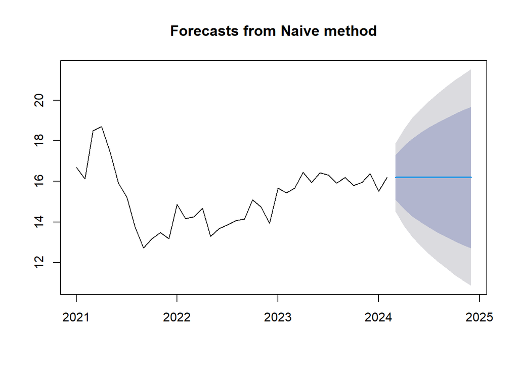

```r
plot(forecast(naive_forecast))
```

- Prediction intervals grow wider with each step, reflecting reduced confidence in long-term predictions.
- Intervals are symmetric around the flat forecast value (16.191), with no directional bias.
- The Naïve method offers limited predictive power beyond short-term stability.
- The Naïve method predicts a flat forecast of 16.191 for all future periods.
- The 80% interval widens over time, starting at [15.087, 17.295] in March 2024 and growing to [12.699, 19.682] by December 2024.
- The 95% interval expands further, indicating increasing uncertainty over time.
- The forecast does not consider seasonality or trends, reflecting the Naïve method’s simplicity.

## Simple Moving Averages

- Simple Moving Averages (SMA) is a basic yet widely used time-series forecasting method. It calculates the average of a fixed number of past observations, updating the average as new data becomes available.

##### Plot the graph for time series.

##### Simple Moving average of order 3, 6, and 9

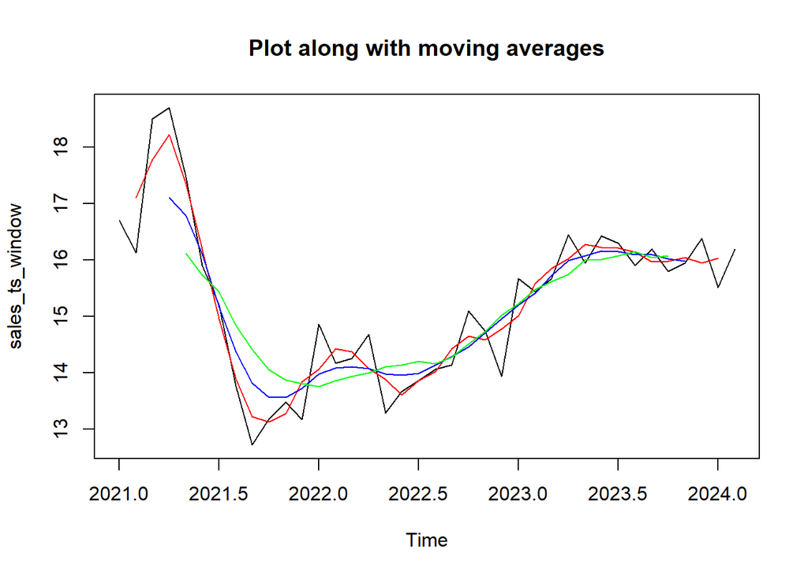

```r
ma3_forecast = ma(sales_ts_window, order = 3)
ma6_forecast = ma(sales_ts_window, order = 6)
ma9_forecast = ma(sales_ts_window, order = 9)
plot(sales_ts_window, main ="Plot along with moving averages")
lines(ma3_forecast, col='Red')
lines(ma6_forecast, col='Blue')
lines(ma9_forecast, col='Green')
```

##### Observations

- Black Line: Represents the original time series with observed fluctuations.
- Red Line (shorter window): Captures short-term trends but follows fluctuations closely.
- Blue and Green Lines (longer windows): Smooth out the data more effectively, reducing noise.
- Trend Observation: Longer moving averages (blue/green) highlight the overall upward trend from 2022 onward.
- Smoothing Effect: Higher smoothing levels reveal underlying patterns while suppressing short-term variations.

[figure not shown]

```r
ma3_forecast = ma(sales_ts_window, order = 3)
plot(sales_ts_window, main ="Plot along with moving averages for 12 Months", h=12)
lines(ma3_forecast, col='Red')
```

##### Observations as Moving Average Order Increases:

- Higher Smoothing: Increasing the order reduces short-term fluctuations and noise, making trends more apparent.
- Lag Effect: Higher-order moving averages lag behind the data, causing a delay in capturing sudden changes.
- Seasonality Loss: As the order increases, seasonal patterns become less visible.
- Best Use: Higher orders are ideal for long-term trend analysis but less effective for detecting short-term variations.

## Simple Smoothing

- Simple Smoothing, also known as Simple Exponential Smoothing (SES), is a forecasting method used for time-series data. It is designed to handle data without trends or seasonality by giving exponentially decreasing weights to past observations, with more weight assigned to recent data points.

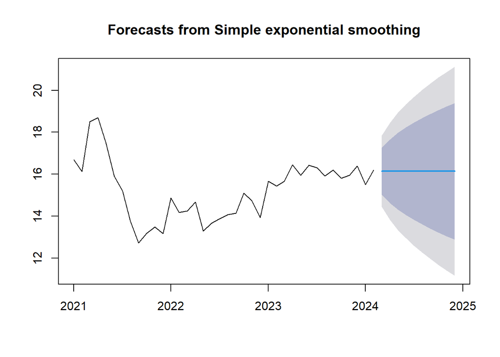

```r
ses_data = ses(sales_ts_window)
plot(ses_data)
```

```r
attributes(ses_data)
```

```
## $names
##  [1] "model"     "mean"      "level"     "x"         "upper"     "lower"
##  [7] "fitted"    "method"    "series"    "residuals"
##
## $class
## [1] "forecast"
```

*Simple Exponential Smoothing: The forecast smooths fluctuations and predicts a stable trend.* Point Forecast: The forecast converges to a consistent value over the horizon. * Prediction Intervals: Uncertainty increases with time, as shown by the widening bands. * Trend Limitation: The method does not account for seasonality or long-term trend changes. * Best Use: Suitable for datasets with no strong trends or seasonality.

```r
summary(ses_data)
```

```
##
## Forecast method: Simple exponential smoothing
##
## Model Information:
## Simple exponential smoothing
##
## Call:
## ses(y = sales_ts_window)
##
##   Smoothing parameters:
##     alpha = 0.9149
##
##   Initial states:
##     l = 16.6662
##
##   sigma:  0.8702
##
##      AIC     AICc      BIC
## 131.6078 132.3137 136.5206
##
## Error measures:
##                       ME      RMSE       MAE        MPE     MAPE      MASE
## Training set -0.01515562 0.8469966 0.6412639 -0.2569269 4.204252 0.3493601
##                      ACF1
## Training set -0.001220629
##
## Forecasts:
##          Point Forecast    Lo 80    Hi 80    Lo 95    Hi 95
## Mar 2024       16.13933 15.02412 17.25455 14.43376 17.84491
## Apr 2024       16.13933 14.62782 17.65085 13.82767 18.45100
## May 2024       16.13933 14.31570 17.96297 13.35032 18.92835
## Jun 2024       16.13933 14.04968 18.22898 12.94349 19.33518
## Jul 2024       16.13933 13.81391 18.46476 12.58290 19.69577
## Aug 2024       16.13933 13.59993 18.67874 12.25565 20.02302
## Sep 2024       16.13933 13.40263 18.87604 11.95390 20.32477
## Oct 2024       16.13933 13.21862 19.06004 11.67249 20.60617
## Nov 2024       16.13933 13.04555 19.23312 11.40779 20.87087
## Dec 2024       16.13933 12.88165 19.39702 11.15714 21.12153
```

##### Observations

- Smoothing Parameter (Alpha): High value (0.9149) indicates strong weighting on recent observations.
- Initial Level (l): Starting level of the forecast is 16.6662.
- sigma: 0.8702 Sigma defines the variance in the forecast predicted.
- Error Measures:
- ME (-0.0152): Minimal bias in forecasts.
- RMSE (0.8470) and MAE (0.6413): Indicate moderate forecast error.
- MAPE (4.20%): Shows good accuracy with small percentage error.
- Prediction Intervals: Widen as forecast horizon increases, reflecting growing uncertainty.
- AIC/BIC: Moderate values (AIC=131.6, BIC=136.5) suggest model fit is reasonable but not optimal.
- ACF1 (-0.0012): Minimal autocorrelation in residuals, indicating well-behaved errors.
- Point Forecast: Stable forecast of 16.13933 for all future months.

##### Residual Analysis

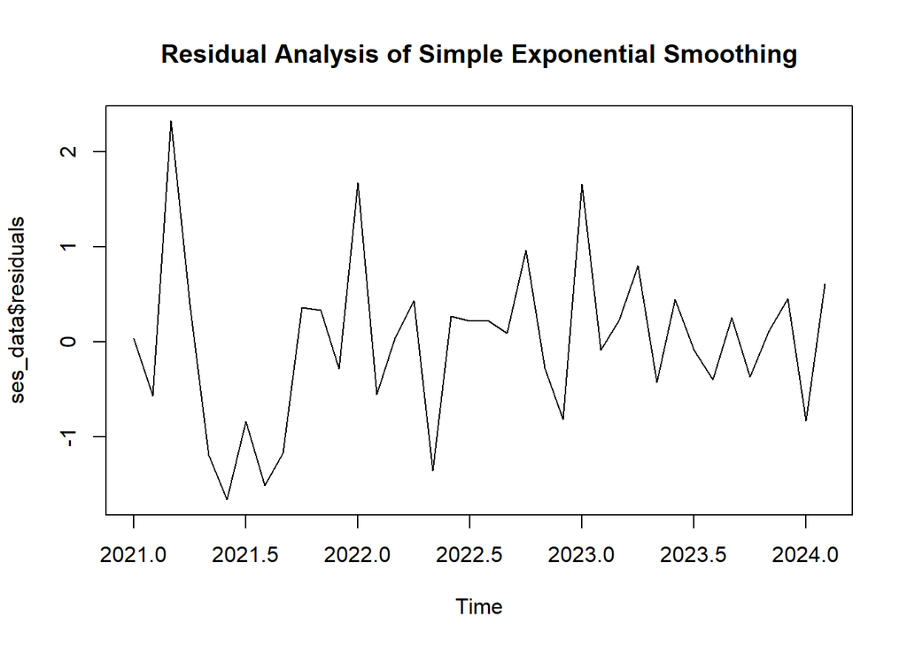

```r
plot(ses_data$residuals, main = "Residual Analysis of Simple Exponential Smoothing")
```

- Residuals fluctuate around zero, indicating no significant bias in the model.
- No clear pattern in residuals, suggesting errors are random and the model fits well.
- Residuals vary between -1 and +2, showing moderate forecasting errors.
- Occasional spikes indicate periods where the model struggles to capture extreme variations.
- Residual behavior suggests the model is appropriate for this time series but could be improved for extreme cases.

###### Histogram plot of residuals

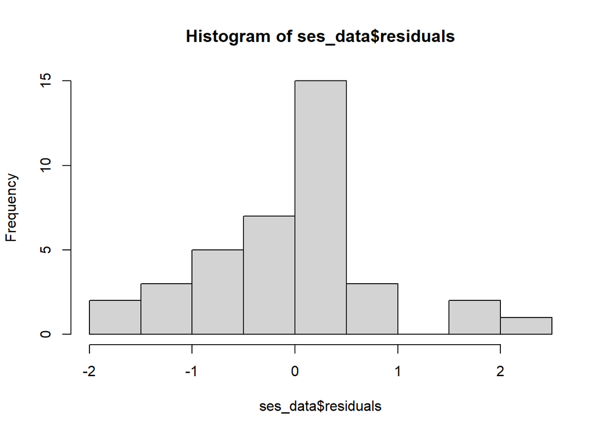

```r
hist(ses_data$residuals)
```

- Residuals are centered around zero, indicating no significant bias in the model.
- Sigma defines the variance in the forecast predicted.
- Slight right skewness, indicating occasional underestimation by the model.
- Residuals range between -2 and +2, showing moderate forecasting errors.
- The model handles the majority of data well but struggles with some extreme cases.